# unit5 practice

Isabella Westlauer

2026-02-01

## Wrangle 3: Relational Data and Regular Expressions

We previously used a dataset called PlayerBBall.csv which contained information about NBA basketball players. To finish that assignment, you had to manipulate the height column.

Review the code you used to do that and see if you can’t make more efficient code using regular expressions and / or the string functions from this Unit.

Use regular expressions to use the height column to create a TotalInches column that has the total height in inches and is recorded as a numeric variable.

Use this variable to make a chart that contains histograms of heights for every position (color coded).

## Get the PlayersBBall Data and inspect it

```r
library(readr)
library(tidyverse)
PlayersBBall <- read_csv("C:/Users/isabe/Desktop/MSDS6306/MSDS_6306_DDS/MSDS_6306_Doing-Data-Science/Unit 2/PlayersBBall.csv")
View(PlayersBBall)
summary(PlayersBBall)
```

```
##      name             year_start      year_end      position
##  Length:4550        Min.   :1947   Min.   :1947   Length:4550
##  Class :character   1st Qu.:1969   1st Qu.:1973   Class :character
##  Mode  :character   Median :1986   Median :1992   Mode  :character
##                     Mean   :1985   Mean   :1989
##                     3rd Qu.:2003   3rd Qu.:2009
##                     Max.   :2018   Max.   :2018
##
##     height              weight       birth_date          college
##  Length:4550        Min.   :114.0   Length:4550        Length:4550
##  Class :character   1st Qu.:190.0   Class :character   Class :character
##  Mode  :character   Median :210.0   Mode  :character   Mode  :character
##                     Mean   :208.9
##                     3rd Qu.:225.0
##                     Max.   :360.0
##                     NA's   :6
```

```r
head(PlayersBBall)
```

```
## # A tibble: 6 × 8
##   name             year_start year_end position height weight birth_date college
##   <chr>                 <dbl>    <dbl> <chr>    <chr>   <dbl> <chr>      <chr>
## 1 Alaa Abdelnaby         1991     1995 F-C      6-10      240 June 24, … Duke U…
## 2 Zaid Abdul-Aziz        1969     1978 C-F      6-9       235 April 7, … Iowa S…
## 3 Kareem Abdul-Ja…       1970     1989 C        7-2       225 April 16,… Univer…
## 4 Mahmoud Abdul-R…       1991     2001 G        6-1       162 March 9, … Louisi…
## 5 Tariq Abdul-Wah…       1998     2003 F        6-6       223 November … San Jo…
## 6 Shareef Abdur-R…       1997     2008 F        6-9       225 December … Univer…
```

## Use regex to convert height into a new column “height_inches”

The new column is a numeric column that relates to the total height of the player in inches.

```r
PlayersBBall <- PlayersBBall %>%
  separate(height, into = c("feet", "inches"), sep = "-", convert = TRUE) %>%
  mutate(height_inches = feet*12 + inches)
head(PlayersBBall[, c("feet", "inches", "height_inches")]) # Quick inspection
```

```
## # A tibble: 6 × 3
##    feet inches height_inches
##   <int>  <int>         <dbl>
## 1     6     10            82
## 2     6      9            81
## 3     7      2            86
## 4     6      1            73
## 5     6      6            78
## 6     6      9            81
```

```r
head(PlayersBBall$height_inches)
```

```
## [1] 82 81 86 73 78 81
```

## Histogram of Height by Position

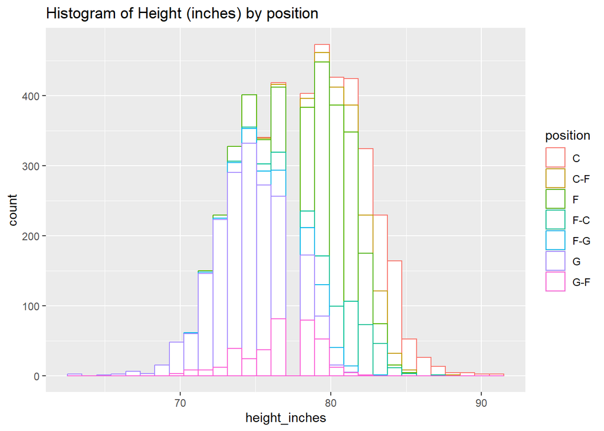

```r
ggplot(PlayersBBall, aes(x = height_inches, color = position)) +
  ggtitle("Histogram of Height (inches) by position") +
  geom_histogram(fill = "white")
```

## FIFA Dataset

Use the string functions and regular expressions to assess a relationship between height and weight among soccer players. To do this you will need to manipulate the height and weight columns into columns that have numeric values of the height and weight.

```r
fifa = read.csv("C:/Users/isabe/Desktop/MSDS6306/MSDS_6306_DDS/doing_data_science/Unit 3 Data Transformation and EDA/FIFA Players.csv", header = TRUE)
head(fifa, 5)
```

```
##   X     ID              Name Age                                          Photo
## 1 0 158023          L. Messi  31 https://cdn.sofifa.org/players/4/19/158023.png
## 2 1  20801 Cristiano Ronaldo  33  https://cdn.sofifa.org/players/4/19/20801.png
## 3 2 190871         Neymar Jr  26 https://cdn.sofifa.org/players/4/19/190871.png
## 4 3 193080            De Gea  27 https://cdn.sofifa.org/players/4/19/193080.png
## 5 4 192985      K. De Bruyne  27 https://cdn.sofifa.org/players/4/19/192985.png
##   Nationality                                Flag Overall Potential
## 1   Argentina https://cdn.sofifa.org/flags/52.png      94        94
## 2    Portugal https://cdn.sofifa.org/flags/38.png      94        94
## 3      Brazil https://cdn.sofifa.org/flags/54.png      92        93
## 4       Spain https://cdn.sofifa.org/flags/45.png      91        93
## 5     Belgium  https://cdn.sofifa.org/flags/7.png      91        92
##                  Club                                    Club.Logo   Value
## 1        FC Barcelona https://cdn.sofifa.org/teams/2/light/241.png €110.5M
## 2            Juventus  https://cdn.sofifa.org/teams/2/light/45.png    €77M
```

[output cut: 63 more lines]

```r
fifa_htwt = fifa %>%
  select("Height", "Weight", "Position")
head(fifa_htwt)
```

```
##   Height Weight Position
## 1    5'7 159lbs       RF
## 2    6'2 183lbs       ST
## 3    5'9 150lbs       LW
## 4    6'4 168lbs       GK
## 5   5'11 154lbs      RCM
## 6    5'8 163lbs       LF
```

Change Height and Weight from text to numbers.  
First, replace the substring “lbs” with “” to remove it.  
Convert the values to numeric datatype, assuming weight is only in whole numbers.

```r
library(stringr)
fifa_htwt$Weight_Num <- str_replace(fifa_htwt$Weight, "lbs", "")
head(fifa_htwt$Weight_Num)
```

```
## [1] "159" "183" "150" "168" "154" "163"
```

```r
# change weight_num from a chr to a dbl
fifa_htwt$Weight_Num <- as.numeric(fifa_htwt$Weight_Num)
head(fifa_htwt)
```

```
##   Height Weight Position Weight_Num
## 1    5'7 159lbs       RF        159
## 2    6'2 183lbs       ST        183
## 3    5'9 150lbs       LW        150
## 4    6'4 168lbs       GK        168
## 5   5'11 154lbs      RCM        154
## 6    5'8 163lbs       LF        163
```

Change height to a number using regex.  
Separate the feet and inches and calculate the height in inches.

```r
#change height to a number
fifa_htwt <- fifa_htwt %>%
  separate(Height, into = c("feet", "inches"), sep = "'", convert = TRUE) %>%
  mutate(height_inches = feet*12 + inches)
head(fifa_htwt)
```

```
##   feet inches Weight Position Weight_Num height_inches
## 1    5      7 159lbs       RF        159            67
## 2    6      2 183lbs       ST        183            74
## 3    5      9 150lbs       LW        150            69
## 4    6      4 168lbs       GK        168            76
## 5    5     11 154lbs      RCM        154            71
## 6    5      8 163lbs       LF        163            68
```

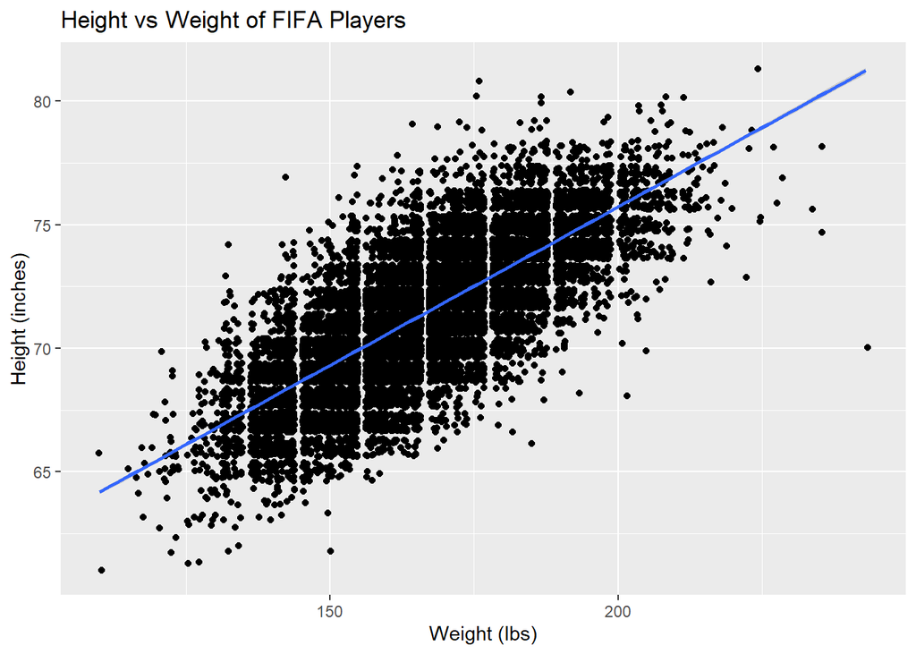

```r
# Plot the height vs weight of players to find any correlation
ggplot(fifa_htwt, aes(x = Weight_Num, y = height_inches)) +
  geom_jitter() +
  geom_smooth(method = "lm") +
  ggtitle("Height vs Weight of FIFA Players") +
  xlab("Weight (lbs)") + ylab("Height (inches)")
```

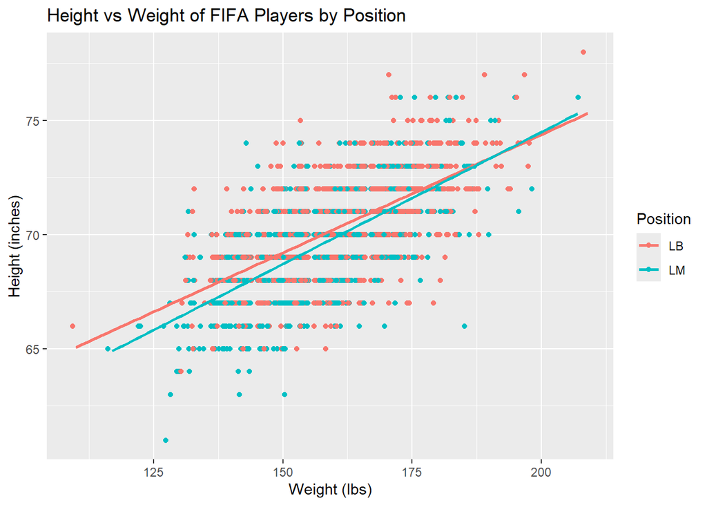

```r
# Look at the linear regression of height vs weight for LM vs LB positions
fifa_htwt %>%
  filter(Position == "LM" | Position == "LB") %>%
  ggplot(aes(x = Weight_Num, y = height_inches, color = Position)) +
  geom_jitter(width = 1, height = 0) +
  geom_smooth(method = "lm", se = FALSE) +
  labs(
    title = "Height vs Weight of FIFA Players by Position",
    x = "Weight (lbs)",
    y = "Height (inches)"
  )
```

## Data Munging

Get the baby name data for 2016.  
The .txt file can be read using readr::read_delim()  
The text files have different delimiters, and no headers.

```r
# Get the baby names
library(readr)
data_2016 <- read_delim("C:/Users/isabe/Desktop/MSDS6306/MSDS_6306_DDS/MSDS_6306_Doing-Data-Science/Unit 5/yob2016.txt",
                        delim = ";", col_names = FALSE)
spec(data_2016)
head(data_2016)
```

```
## # A tibble: 6 × 3
##   X1       X2       X3
##   <chr>    <chr> <dbl>
## 1 Emma     F     19414
## 2 Olivia   F     19246
## 3 Ava      F     16237
## 4 Sophia   F     16070
## 5 Isabella F     14722
## 6 Mia      F     14366
```

Read the data into a data frame. Change the column names to be more descriptive.

```r
df_baby <- data.frame(data_2016)

# give it human readable column names
df_baby <- rename(df_baby, Name = X1, Gender = X2, Count = X3)
summary(df_baby)
```

```
##      Name              Gender              Count
##  Length:32869       Length:32869       Min.   :    5.0
##  Class :character   Class :character   1st Qu.:    7.0
##  Mode  :character   Mode  :character   Median :   12.0
##                                        Mean   :  110.7
##                                        3rd Qu.:   30.0
##                                        Max.   :19414.0
```

```r
head(df_baby)
```

```
##       Name Gender Count
## 1     Emma      F 19414
## 2   Olivia      F 19246
## 3      Ava      F 16237
## 4   Sophia      F 16070
## 5 Isabella      F 14722
## 6      Mia      F 14366
```

Find names with three y’s at the end.  
Remove the misspelled name.

```r
# Find names with three y's at the end
str(df_baby)
```

```
## 'data.frame':    32869 obs. of  3 variables:
##  $ Name  : chr  "Emma" "Olivia" "Ava" "Sophia" ...
##  $ Gender: chr  "F" "F" "F" "F" ...
##  $ Count : num  19414 19246 16237 16070 14722 ...
```

```r
str_view_all(df_baby$Name,"yyy$") # can't see results- returns the whole column
```

```
##  [1] │ Emma
##  [2] │ Olivia
##  [3] │ Ava
##  [4] │ Sophia
##  [5] │ Isabella
##  [6] │ Mia
##  [7] │ Charlotte
##  [8] │ Abigail
##  [9] │ Emily
## [10] │ Harper
## [11] │ Amelia
## [12] │ Evelyn
## [13] │ Elizabeth
## [14] │ Sofia
## [15] │ Madison
## [16] │ Avery
## [17] │ Ella
## [18] │ Scarlett
## [19] │ Grace
## [20] │ Chloe
## ... and 32849 more
```

```r
df_baby %>%
  filter(str_detect(df_baby$Name,"yyy$"))
```

```
##       Name Gender Count
## 1 Fionayyy      F  1547
```

```r
#Check to make sure the data to keep is there, too
df_baby %>%
  filter(str_detect(Name, "Fiona"))
```

```
##       Name Gender Count
## 1    Fiona      F  1547
## 2 Fionayyy      F  1547
```

```r
y2016 <- df_baby %>%
  filter(!str_detect(df_baby$Name,"yyy$"))

#check to make sure it's removed
y2016 %>%
  filter(str_detect(Name,"yyy$"))
```

```
## [1] Name   Gender Count
## <0 rows> (or 0-length row.names)
```

```r
summary(y2016)
```

```
##      Name              Gender              Count
##  Length:32868       Length:32868       Min.   :    5.0
##  Class :character   Class :character   1st Qu.:    7.0
##  Mode  :character   Mode  :character   Median :   12.0
##                                        Mean   :  110.7
##                                        3rd Qu.:   30.0
##                                        Max.   :19414.0
```

## Data Merging

Get the last ten rows of 2015 baby names.  
Put the data in a dataframe and give it human readable column names.

```r
library(readr)
data_2015 <- read_delim("C:/Users/isabe/Desktop/MSDS6306/MSDS_6306_DDS/MSDS_6306_Doing-Data-Science/Unit 5/yob2015.txt",
                        delim = ",", col_names = FALSE)
spec(data_2015)
df_baby_2015 <- data.frame(data_2015)
df_baby_2015 <- rename(df_baby_2015, Name = X1, Gender = X2, Count = X3)
tail(df_baby_2015, 10)
```

```
##         Name Gender Count
## 33054   Ziyu      M     5
## 33055   Zoel      M     5
## 33056  Zohar      M     5
## 33057 Zolton      M     5
## 33058   Zyah      M     5
## 33059 Zykell      M     5
## 33060 Zyking      M     5
## 33061  Zykir      M     5
## 33062  Zyrus      M     5
## 33063   Zyus      M     5
```

Merge y2016 and y2015 by your Name column; assign it to final. The client only cares about names that have data for both 2016 and 2015; there should be no NA values in either of your amount of children rows after merging.

```r
library(dplyr)
library(plotly)
# filter out N/A
final <- merge(na.omit(y2016), na.omit(df_baby_2015), by = "Name", relationship = "many-to-many")

# no name should be on the list more than once... let's check, how?
# print(table(final$Name)) # too much console output
# as.data.frame(table(final$Name)) %>% plot() # all at 1.0, 2.0, and 4.0 why?
# hist(as.factor(final$Name)) # This doesn't work because I changed Name to str

final %>% filter(Name == "Emma") %>% head()
```

```
##   Name Gender.x Count.x Gender.y Count.y
## 1 Emma        F   19414        M      10
## 2 Emma        F   19414        F   20415
## 3 Emma        M      18        M      10
## 4 Emma        M      18        F   20415
```

```r
head(final)
```

```
##        Name Gender.x Count.x Gender.y Count.y
## 1     Aaban        M       9        M      15
## 2     Aabha        F       7        F       7
## 3 Aabriella        F      11        F       5
## 4     Aadam        M      18        M      22
## 5   Aadarsh        M      11        M      15
## 6     Aaden        M     194        M     297
```

```r
summary(final) # Would summary tell me if there is any NA? nope
```

```
##      Name             Gender.x            Count.x          Gender.y
##  Length:31641       Length:31641       Min.   :    5.0   Length:31641
##  Class :character   Class :character   1st Qu.:    8.0   Class :character
##  Mode  :character   Mode  :character   Median :   16.0   Mode  :character
##                                        Mean   :  179.2
##                                        3rd Qu.:   45.0
##                                        Max.   :19414.0
##     Count.y
##  Min.   :    5.0
##  1st Qu.:    8.0
##  Median :   16.0
##  Mean   :  181.3
##  3rd Qu.:   46.0
##  Max.   :20415.0
```

```r
final <- merge(na.omit(y2016), na.omit(df_baby_2015), by = c("Name", "Gender"))
final %>% filter(Name == "Emma") %>% head()
```

```
##   Name Gender Count.x Count.y
## 1 Emma      F   19414   20415
## 2 Emma      M      18      10
```

```r
head(final)
```

```
##        Name Gender Count.x Count.y
## 1     Aaban      M       9      15
## 2     Aabha      F       7       7
## 3 Aabriella      F      11       5
## 4     Aadam      M      18      22
## 5   Aadarsh      M      11      15
## 6     Aaden      M     194     297
```

## Data Summary

Create a new column called “Total” in final that adds the amount of children in 2015 and 2016 together. In those two years combined, how many people were given popular names? Sort the data by Total. What are the top 10 most popular names? The client is expecting a girl! Omit boys and give the top 10 most popular girl’s names. Write these top 10 girl names and their Totals to a CSV file. Leave out the other columns entirely.

```r
# combine counts from 2015 and 2016
final$Total = final$Count.x + final$Count.y
head(final)
```

```
##        Name Gender Count.x Count.y Total
## 1     Aaban      M       9      15    24
## 2     Aabha      F       7       7    14
## 3 Aabriella      F      11       5    16
## 4     Aadam      M      18      22    40
## 5   Aadarsh      M      11      15    26
## 6     Aaden      M     194     297   491
```

```r
tail(final)
```

```
##         Name Gender Count.x Count.y Total
## 26545  Zyren      M      10       9    19
## 26546  Zyria      F      11       6    17
## 26547 Zyriah      F      24      27    51
## 26548 Zyrion      M       8       7    15
## 26549  Zyron      M      12      15    27
## 26550  Zyrus      M       6       5    11
```

```r
summary(final$Total)
```

```
##    Min. 1st Qu.  Median    Mean 3rd Qu.    Max.
##    10.0    17.0    31.0   272.7    81.0 39829.0
```

```r
# What are the top 5% of most popular baby names?
cutoff_95 <- quantile(final$Total, 0.95)
cutoff_99 <- quantile(final$Total, 0.99)

top_5_percent <- final %>%
  filter(Total >= cutoff_95)
summary(top_5_percent)
```

```
##      Name              Gender             Count.x         Count.y
##  Length:1330        Length:1330        Min.   :  345   Min.   :  299.0
##  Class :character   Class :character   1st Qu.:  612   1st Qu.:  607.5
##  Mode  :character   Mode  :character   Median : 1004   Median : 1001.0
##                                        Mean   : 2009   Mean   : 2041.7
##                                        3rd Qu.: 2106   3rd Qu.: 2208.0
##                                        Max.   :19414   Max.   :20415.0
##      Total
##  Min.   :  823
##  1st Qu.: 1230
##  Median : 1998
##  Mean   : 4051
##  3rd Qu.: 4290
##  Max.   :39829
```

```r
top_1_percent <- final %>%
  filter(Total >= cutoff_99)
summary(top_1_percent)
```

```
##      Name              Gender             Count.x         Count.y
##  Length:266         Length:266         Min.   : 2520   Min.   : 2403
##  Class :character   Class :character   1st Qu.: 3399   1st Qu.: 3445
##  Mode  :character   Mode  :character   Median : 4814   Median : 4864
##                                        Mean   : 6049   Mean   : 6191
##                                        3rd Qu.: 7385   3rd Qu.: 7608
##                                        Max.   :19414   Max.   :20415
##      Total
##  Min.   : 5416
##  1st Qu.: 6865
##  Median : 9666
##  Mean   :12240
##  3rd Qu.:14896
##  Max.   :39829
```

## Plot the Popular Baby Names

[figure not shown]

```r
ggplot(top_1_percent, aes(x = reorder(Name, Total), y = Total, label = Total)) +
  geom_col(fill = "steelblue") +
  geom_label(aes(label = Total),
             nudge_x = 0.25, nudge_y = 0.25,
             fill = "lightblue", color = "black") +
  coord_flip() +
  labs(
    title = "Top 20 Most Popular Baby Names 2015-2016",
    x = "Baby Name",
    y = "Total Count"
  ) +
  theme_minimal()
```

## Most Popular Girl’s Names

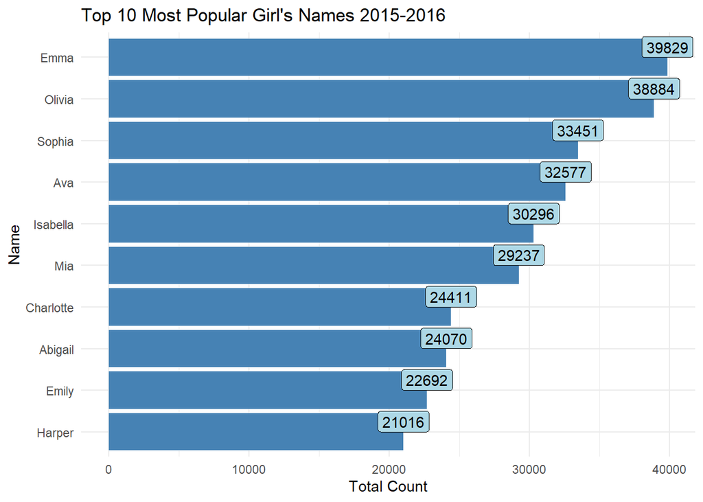

```r
# filter to girls names only
popular_girls <-
final %>%
  filter(Gender == "F") %>%
  select(Name, Total) %>%
  arrange(desc(Total)) %>%
  head(10)

# plot the 10 most popular girl's names
top_1_percent %>%
  filter(Gender == "F") %>%
  arrange(desc(Total)) %>%
  slice_head(n = 10) %>%
ggplot(aes(x = reorder(Name, Total), y = Total, label = Total)) +
  geom_col(fill = "steelblue") +
  geom_label(aes(label = Total),
             nudge_x = 0.25, nudge_y = 0.25,
             fill = "lightblue", color = "black") +
  coord_flip() +
  labs(
    title = "Top 10 Most Popular Girl's Names 2015-2016",
    x = "Name",
    y = "Total Count"
  ) +
  theme_minimal()
```

```r
# Write the result to a csv file
write.csv(popular_girls, file = "Top Ten Girls Names 2015-2016.csv", row.names = FALSE)
```